# Introduction to Biostatistics

# 1 Learning objectives

## 1.1 Learning objectives

- **Conduct** Poisson regression for *count outcomes*
- **Interpret** results in terms of *predicted counts*
- **Describe** when to use alternative models / specifications
  - Negative binomial, inflated zeroes, offset, etc.

# 2 Linear regression review

## 2.1 Assumptions of linear regression

- Linear regression (GLM) makes 3 assumptions about the residuals ($e_i = Y_i - \hat{Y}_i$) of the model
  - Independence
  - Constant variance
  - Conditional normality

# 3 Count variables

## 3.1 What is a count?

- **Count variables** occur any time you **count** the number of times an event occurs in a *fixed period of time*
  - Number of visits to doctor in past 6 months
  - Number of days of poor QOL per month
  - Number of cigarettes smoked in a day
  - Number of gene repeats in a sample
  - Number of adverse events in a study

## 3.2 Count outcomes in medical research

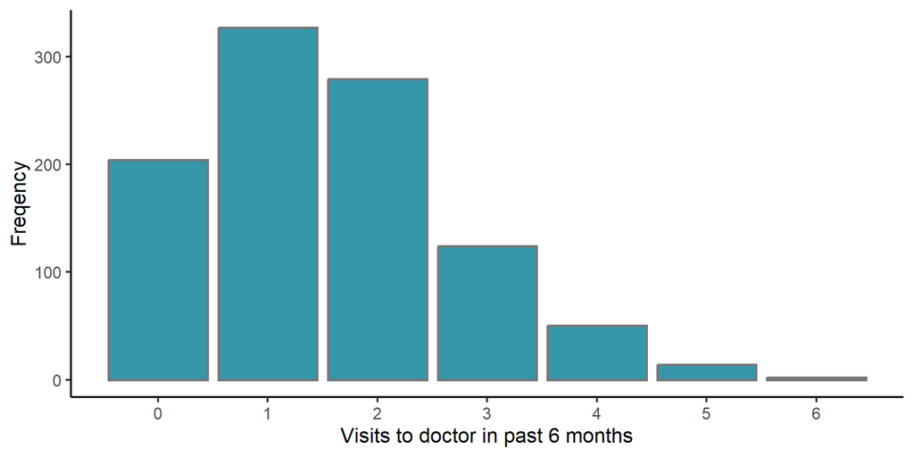

```r
count1 <- rpois(n = 1000, lambda = 1.5)
count_dat <- as.data.frame(count1)
ggplot(data = count_dat, aes(count1)) +
    geom_bar(fill = "#3697aa", color = "#76777a", size = 1) +
    labs(x = "Visits to doctor in past 6 months", y = "Freqency") +
    scale_x_continuous(breaks = c(0:12))
```

## 3.3 Count variable properties

- Always
  - Discrete (whole numbers)
  - Lower bound of 0
- Typically
  - Low mean
  - High frequency of 0 values
  - Right skewed
  - Heteroskedasticity

## 3.4 Example data: Alcohol use

- Simulated data<sup>1</sup> made to resemble real data<sup>2</sup>
- Outcome: **Number** of alcoholic drinks consumed *last Saturday*
  - Ranges from 0 to 17
- Predictors
  - Sensation seeking: 3 to 7 (theoretically 1 to 7)
  - Sex: 0 = female, 1 = male
[^1]: Simulated data in Coxe, West, & Aiken (2009)
[^2]: Real data in DeHart, Tennen, Armeli, Todd, & Affleck (2008)

## 3.5 A count variable is not normal

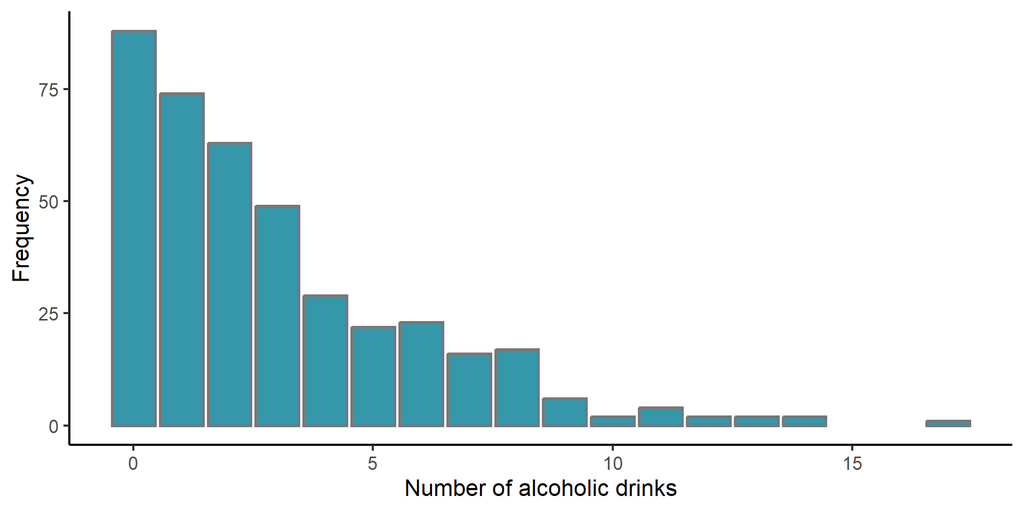

```r
library(readr)
dat <- read_table("jpapoisson.txt",
    col_names = FALSE)
colnames(dat) <- c("ID", "sensation", "sex", "alcohol")
ggplot(data = dat, aes(x = alcohol)) +
    geom_bar(fill = "#3697aa", color = "#76777a", size = 1) +
    labs(x = "Number of alcoholic drinks", y = "Frequency")
```

## 3.6 Linear regression on count

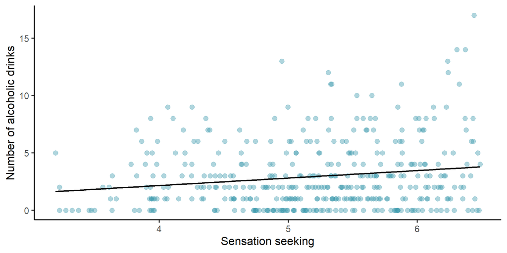

```r
ggplot(data = dat, aes(x = sensation, y = alcohol)) +
    geom_point(size = 3,
               alpha = 0.4,
               color = "#3697aa") +
  geom_smooth(method = "lm",
              se = FALSE,
              color = "black") +
  labs(x = "Sensation seeking", y = "Number of alcoholic drinks")
```

## 3.7 Residuals for linear regression

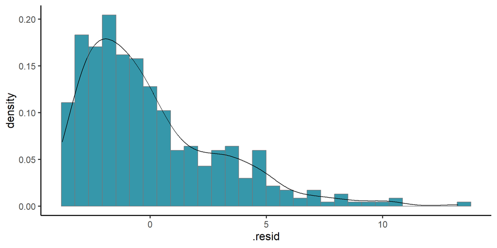

```r
m1_lin <- lm(data = dat, alcohol ~ sensation)
resids_m1_lin <- augment(m1_lin)
ggplot(data = resids_m1_lin,
       aes(x = .resid)) +
  geom_histogram(aes(y = ..density..),
                 fill = "#3697aa",
                 color = "#76777a") +
  geom_density()
```

## 3.8 Residuals for linear regression

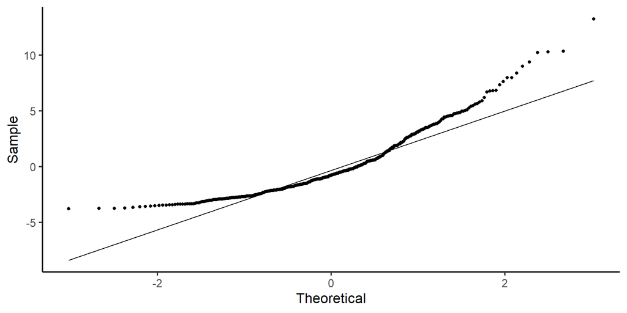

```r
ggplot(data = resids_m1_lin,
       aes(sample = .resid)) +
  geom_qq() +
  geom_qq_line() +
  labs(x = "Theoretical",
       y = "Sample")
```

## 3.9 Residuals vs predictor

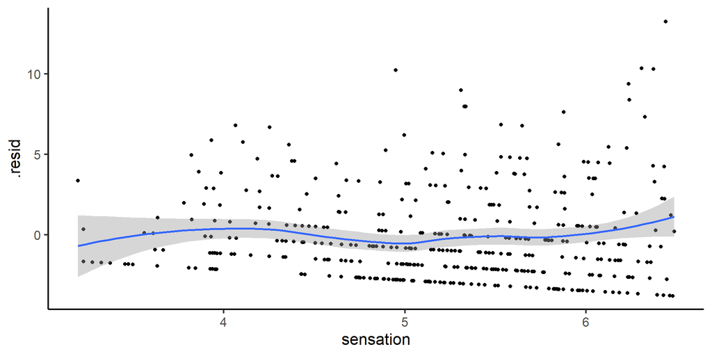

```r
ggplot(data = resids_m1_lin,
       aes(x = sensation,
           y = .resid)) +
  geom_point() +
  geom_smooth()
```

## 3.10 Residuals vs predictor

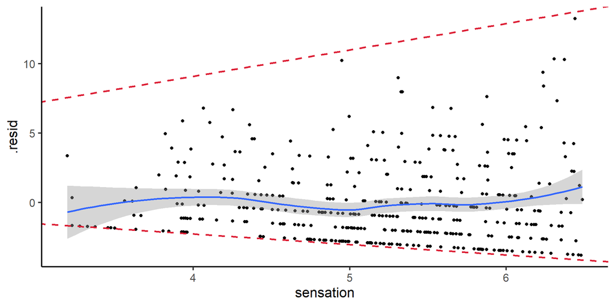

```r
ggplot(data = resids_m1_lin,
       aes(x = sensation,
           y = .resid)) +
  geom_point() +
  geom_smooth() +
  geom_abline(intercept = 0.75,
                slope = -0.75,
                color = "#dc1e34",
                size = 1,
                linetype = "dashed") +
    geom_abline(intercept = 1.5,
                slope = 1.9,
                color = "#dc1e34",
                size = 1,
                linetype = "dashed")
```

## 3.11 What **NOT** to do

- **Ignore** the problem
  - Do linear regression anyway
  - Get biased estimates and out-of-range prediction
- **Transform** the *outcome*
  - Square root, natural log, etc.
  - May *slightly* normalize *univariate* residual distribution
  - **Does not fix heteroscedasticity, (conditional) non-normality**

## 3.12 Transform the outcome - ugh!

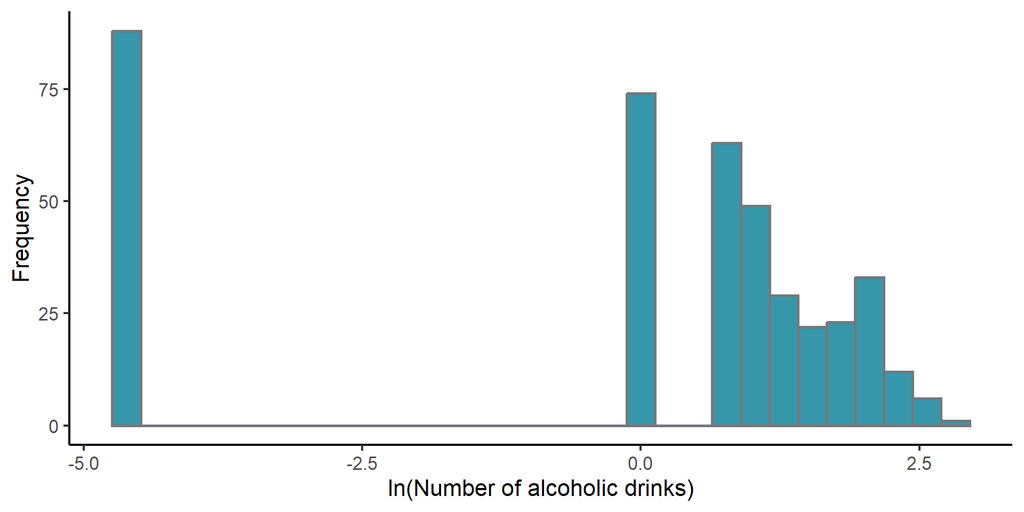

```r
dat2 <- dat %>%
    mutate(lnalc = log(alcohol + 0.01))
ggplot(data = dat2, aes(x = lnalc)) +
    geom_histogram(fill = "#3697aa",
                   color = "#76777a",
                   size = 1) +
    labs(x = "ln(Number of alcoholic drinks)", y = "Frequency")
```

## 3.13 Transform the outcome - ugh!

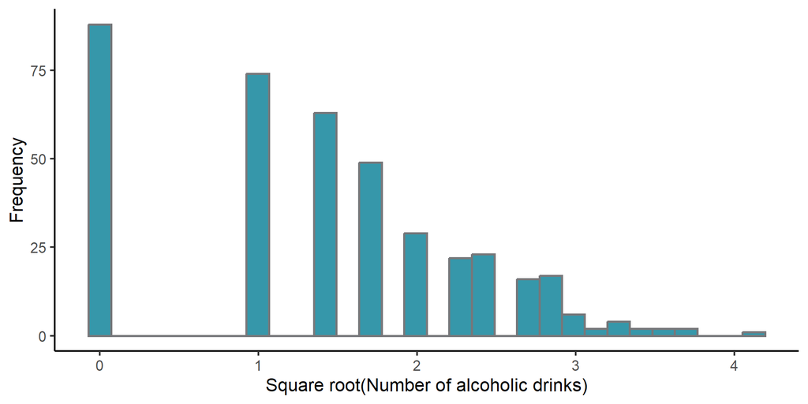

```r
dat2 <- dat2 %>%
    mutate(sqrtalc = sqrt(alcohol))
ggplot(data = dat2, aes(x = sqrtalc)) +
    geom_histogram(fill = "#3697aa",
                   color = "#76777a",
                   size = 1) +
    labs(x = "Square root(Number of alcoholic drinks)", y = "Frequency")
```

## 3.14 What to do

- **Generalized linear model (GLiM)**
  - Not a single model but a **family** of regression models
  - **Choose** features (e.g., residual distribution) to match the **characteristics** of your outcome variable
  - Accommodates many **continuous** and **categorical** outcome variables
  - Includes **logistic regression** and **Poisson regression**
  - Transformation of the **predicted** outcome

# 4 Poisson regression

## 4.1 Poisson regression

- **Outcome**: count in a *fixed period of time*
  - Discrete, lower bound of zero, often right skewed
- **Residual / outcome distribution**: Poisson
- **Link function**: natural log = $ln(\hat{Y}) = ln(\hat{\mu})$

$$ln(\hat{\mu}) = b_0 + b_1 X_1 + b_2 X_2 + \cdots + b_p X_p$$

## 4.2 Reminder: normal distribution

$$f(x) = {\frac {1}{{\sqrt {2\pi \sigma^2}}}}e^{-{\frac {(x-\mu)^2 }{2 \sigma^2 }}}$$

Mean of normal distribution = $\mu$

Variance of normal distribution = $\sigma^2$

- Mean and variance are **different parameters** and are **unrelated**
  - **Homoscedasticity**: Constant variance doesn’t depend on mean

## 4.3 Poisson distribution

- Developed by Simeon Denis Poisson (1781 - 1840)
- **Number of times** a **low probability** event happens
  - Number of soldiers killed by horse-kicks each year in each corps in the Prussian cavalry (Bortkiewicz)
  - Number of yeast cells used when brewing Guinness beer
  - Number of typographical errors on each page of a book
  - Number of bombs falling in London in each block during Blitz
  - Number of earthquakes per day in Southern California

## 4.4 Poisson distribution

$$P(X = k) = \frac{\lambda^k}{k!}e^{-\lambda}$$

- **Poisson distribution** is
  - *Discrete*
  - *Undefined for values less than 0*
  - *Right skewed* when *mean is low*
  - $\lambda =$ mean *and* variance: Heteroscedasticity

## 4.5 Poisson: mean = variance = 1

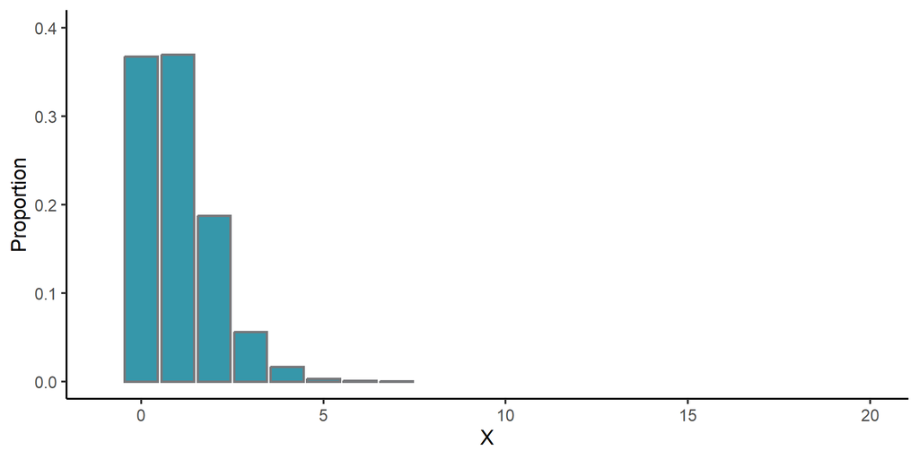

```r
pois_1 <- rpois(10000, 1)
pois_1_data <- data.frame(pois_1)
ggplot(data = pois_1_data, aes(x = pois_1)) +
    geom_bar(aes(y = (..count..)/sum(..count..)),
             fill = "#3697aa", color = "#76777a", size = 1) +
    labs(x = "X", y = "Proportion") +
    xlim(-1, 20) +
    ylim(0, .400)
```

## 4.6 Poisson: mean = variance = 4

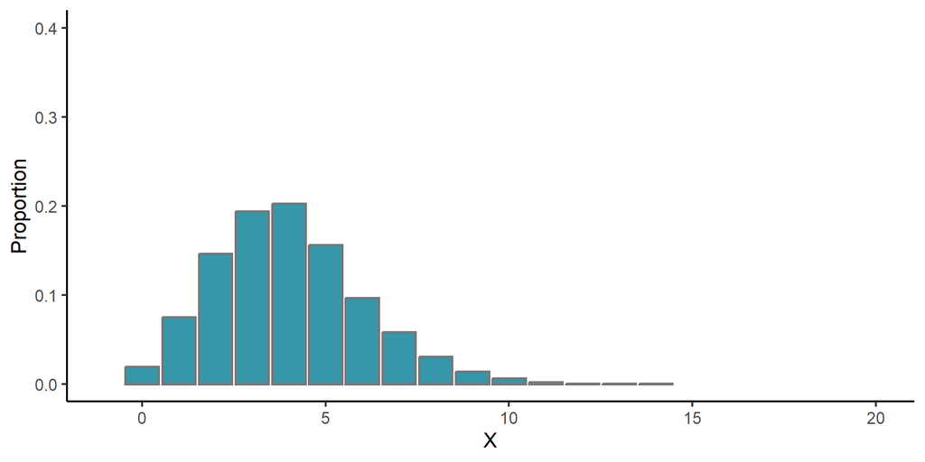

```r
pois_4 <- rpois(10000, 4)
pois_4_data <- data.frame(pois_4)
ggplot(data = pois_4_data, aes(x = pois_4)) +
    geom_bar(aes(y = (..count..)/sum(..count..)),
             fill = "#3697aa", color = "#76777a", size = 1) +
    labs(x = "X", y = "Proportion") +
    xlim(-1, 20) +
    ylim(0, .400)
```

## 4.7 Poisson: mean = variance = 7

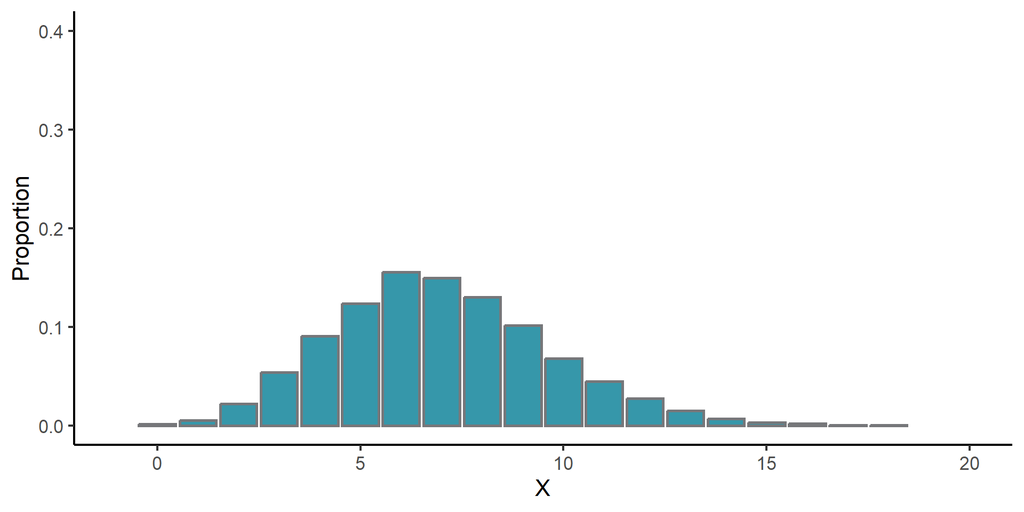

```r
pois_7 <- rpois(10000, 7)
pois_7_data <- data.frame(pois_7)
ggplot(data = pois_7_data, aes(x = pois_7)) +
    geom_bar(aes(y = (..count..)/sum(..count..)),
             fill = "#3697aa", color = "#76777a", size = 1) +
    labs(x = "X", y = "Proportion") +
    xlim(-1, 20) +
    ylim(0, .400)
```

## 4.8 Poisson: mean = variance = 10

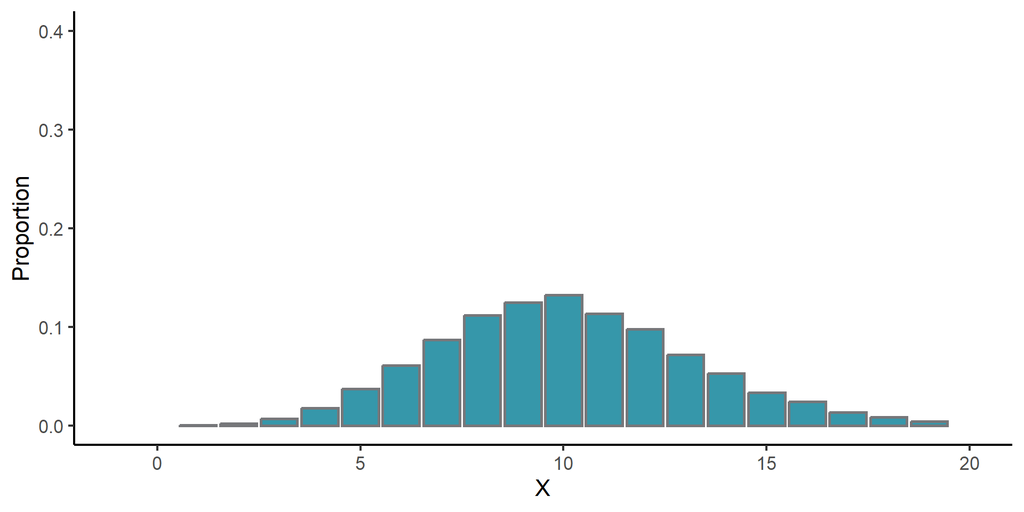

```r
pois_10 <- rpois(10000, 10)
pois_10_data <- data.frame(pois_10)
ggplot(data = pois_10_data, aes(x = pois_10)) +
    geom_bar(aes(y = (..count..)/sum(..count..)),
             fill = "#3697aa", color = "#76777a", size = 1) +
    labs(x = "X", y = "Proportion") +
    xlim(-1, 20) +
    ylim(0, .400)
```

## 4.9 Poisson regression model

- `glm()` function in **stats** package (always loaded)
  - `data`: same as `lm()`
  - `formula`: same as `lm()`
  - `family`: Residual distribution and link function

```r
dat <- dat %>% mutate(sensationC = sensation - mean(sensation, na.rm = TRUE))
m1 <- glm(data = dat,
          alcohol ~ sensationC,
          family = poisson(link = "log"))
```

```r
m1_b0 <- round(coefficients(m1)[1], 3)
m1_b1 <- round(coefficients(m1)[2], 3)
```

## 4.10 Poisson regression model

- Estimate
- Standard error
- **$z$ statistic**
- $p$-value
- **No $R^2$**
- Deviance

```r
summary(m1)
```

```
Call:
glm(formula = alcohol ~ sensationC, family = poisson(link = "log"),
    data = dat)

Coefficients:
            Estimate Std. Error z value Pr(>|z|)
(Intercept)  1.05963    0.02967  35.715  < 2e-16 ***
sensationC   0.23148    0.03966   5.837 5.33e-09 ***
---
Signif. codes:  0 '***' 0.001 '**' 0.01 '*' 0.05 '.' 0.1 ' ' 1

(Dispersion parameter for poisson family taken to be 1)

    Null deviance: 1186.8  on 399  degrees of freedom
Residual deviance: 1151.7  on 398  degrees of freedom
AIC: 2079

Number of Fisher Scoring iterations: 5
```

## 4.11 Two forms of Poisson regression

Predicted count:

$$\hat{\mu} = e^{\color{OrangeRed}{b_0 + b_1 X_1 + b_2 X_2 + \cdots + b_p X_p}}$$

Natural log of predicted count:

$$ln(\hat{\mu}) = \color{OrangeRed}{b_0 + b_1 X_1 + b_2 X_2 + \cdots + b_p X_p}$$

## 4.12 Predicted count interpretation

$$\hat{\mu} = e^{b_0 + b_1 X}$$

- Intercept
  - $e^{b_0}$ is the **predicted count** when **$X$ = 0**
- Slope
  - $e^{b_1}$ is the **rate ratio**
  - For a 1 unit increase in $X$, the predicted count is **multiplied by** $e^{b_1}$

## 4.13 Example: $\hat{\mu} = e^{1.06 + 0.231 \times sensationC}$

- Intercept = $e^{b_0} = e^{1.06} = 2.886$
  - People with mean value of `sensation` are expected to drink 2.886 alcoholic drinks
- Slope = $e^{b_1} = e^{0.231} = 1.26$
  - **Multiplicative** effect of $X$ on the predicted count
  - For a one unit increase in `sensation`, the number of predicted alcoholic drinks is **multiplied** by 1.26
  - Also: 26$\%$ increase in the predicted outcome for each one unit increase in `sensation`

## 4.14 Predicted counts: $e^{b_1} = 1.26$

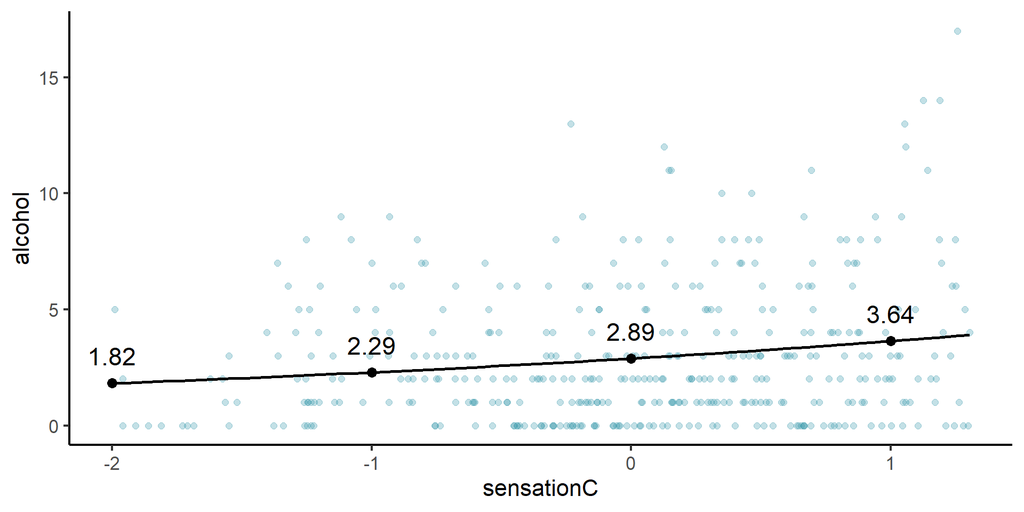

```r
sens_vals <- data.frame(sensationC = c(-2, -1, 0, 1))
pred_counts <- predict(m1, newdata = sens_vals, type = "response")
sensationC <- c(-2, -1, 0, 1)
pred_alc <- c(1.82, 2.29, 2.89, 3.64)
pred_counts <- data.frame(sensationC, pred_alc)
ggplot(dat,
       aes(x=sensationC,
           y=alcohol)) +
  geom_point(color = "#3697aa",
             alpha = 0.3,
             size = 2) +
  stat_smooth(method="glm",
              method.args=list(family="poisson"),
              se=FALSE,
              color = "black") +
  geom_point(data = pred_counts,
             aes(x = sensationC, y = pred_alc),
             size = 3,
             color = "black") +
  annotate("text", x = -2, y = 1.82,
           label = "1.82", vjust = -1, size = 6) +
  annotate("text", x = -1, y = 2.29,
           label = "2.29", vjust = -1, size = 6) +
  annotate("text", x = 0, y = 2.89,
           label = "2.89", vjust = -1, size = 6) +
  annotate("text", x = 1, y = 3.64,
           label = "3.64", vjust = -1, size = 6)
```

## 4.15 Confidence intervals: Natural log

- Original coefficients and confidence intervals
  - Natural log of predicted count metric

```r
coef(m1)
```

```
(Intercept)  sensationC
  1.0596254   0.2314809
```

```r
confint(m1)
```

```
                2.5 %    97.5 %
(Intercept) 1.0008860 1.1172000
sensationC  0.1541381 0.3096215
```

- Do they contain 0?

## 4.16 Confidence intervals: Predicted count

- Exponentiate estimates and confidence intervals
  - **Predicted count** metric

```r
exp(coef(m1))
```

```
(Intercept)  sensationC
   2.885290    1.260465
```

```r
exp(confint(m1))
```

```
               2.5 %   97.5 %
(Intercept) 2.720691 3.056284
sensationC  1.166652 1.362909
```

- Do they contain 1?

# 5 (Over)Dispersion

## 5.1 Equidispersion

- Poisson distribution displays **equidisersion**
  - Conditional mean = conditional variance = $\lambda$
- In practice in data, the actual variance of $Y$ is typically **larger** than expected (i.e., larger than the mean)
  - This is called **overdispersion**

## 5.2 Why does overdispersion happen?

- Sometimes, just because
- Due to omitted predictors
  - Something we should include but are not
  - New predictors affect the **mean**
    - Heteroscedasticity: They can impact variance
- “Excess” zeroes
  - **Looks like** more variance

## 5.3 Why do we care?

- The variance estimated in the model ($\lambda$) helps determine the **standard errors** for regression coefficients
- It also plays a role in calculating **deviance**
- **If the variance in our data is larger than $\lambda$, the standard errors are too small and the deviance is wrong**
  - Test of significance, pseudo-$R^2$, model comparisons are **wrong**

## 5.4 Is there overdispersion?

- Quick check: Residual deviance / degrees of freedom > 1

```r
summary(m1)
```

```
Call:
glm(formula = alcohol ~ sensationC, family = poisson(link = "log"),
    data = dat)

Coefficients:
            Estimate Std. Error z value Pr(>|z|)
(Intercept)  1.05963    0.02967  35.715  < 2e-16 ***
sensationC   0.23148    0.03966   5.837 5.33e-09 ***
---
Signif. codes:  0 '***' 0.001 '**' 0.01 '*' 0.05 '.' 0.1 ' ' 1

(Dispersion parameter for poisson family taken to be 1)

    Null deviance: 1186.8  on 399  degrees of freedom
Residual deviance: 1151.7  on 398  degrees of freedom
AIC: 2079

Number of Fisher Scoring iterations: 5
```

## 5.5 Adding a predictor

- Can reduce overdispersion

```r
m1add <- glm(data = dat,
          alcohol ~ sensationC + sex,
          family = poisson(link = "log"))
summary(m1add)
```

```
Call:
glm(formula = alcohol ~ sensationC + sex, family = poisson(link = "log"),
    data = dat)

Coefficients:
            Estimate Std. Error z value Pr(>|z|)
(Intercept)  0.56334    0.05248  10.734  < 2e-16 ***
sensationC   0.26085    0.03882   6.719 1.83e-11 ***
sex          0.83947    0.06292  13.342  < 2e-16 ***
---
Signif. codes:  0 '***' 0.001 '**' 0.01 '*' 0.05 '.' 0.1 ' ' 1

(Dispersion parameter for poisson family taken to be 1)

    Null deviance: 1186.76  on 399  degrees of freedom
Residual deviance:  959.46  on 397  degrees of freedom
AIC: 1888.8

Number of Fisher Scoring iterations: 5
```

## 5.6 What do we do?

- There are two main alternative models for overdispersion
  - **Overdispersed Poisson regression** a.k.a. quasi-Poisson regression
    - *Same coefficients*, adjusted standard errors
  - **Negative binomial regression**
    - Different coefficients, different standard errors
- Both handle overdispersion, but in slightly different ways

## 5.7 Overdispersed Poisson regression

- “Fudge factor”
  - Variance is larger than the model says, so multiply variance by something to make it larger
- Scale parameter: $\psi = \frac{\chi^2_{Pearson}}{residual\ df}$ or $\frac{deviance}{residual\ df}$
  - If equidispersion holds: $\psi = 1$
  - If overdispserion: $\psi > 1$
  - Compared to Poisson: Each standard error $\times \sqrt{\psi}$

## 5.8 Overdispersed Poisson regression

```r
m2 <- glm(data = dat,
          alcohol ~ sensationC,
          family = quasipoisson)
summary(m2)
```

```
Call:
glm(formula = alcohol ~ sensationC, family = quasipoisson, data = dat)

Coefficients:
            Estimate Std. Error t value Pr(>|t|)
(Intercept)  1.05963    0.05006  21.166  < 2e-16 ***
sensationC   0.23148    0.06692   3.459 0.000601 ***
---
Signif. codes:  0 '***' 0.001 '**' 0.01 '*' 0.05 '.' 0.1 ' ' 1

(Dispersion parameter for quasipoisson family taken to be 2.847168)

    Null deviance: 1186.8  on 399  degrees of freedom
Residual deviance: 1151.7  on 398  degrees of freedom
AIC: NA

Number of Fisher Scoring iterations: 5
```

## 5.9 Compare Poisson to OD Poisson

- Poisson regression

```r
summary(m1)
```

```
Call:
glm(formula = alcohol ~ sensationC, family = poisson(link = "log"),
    data = dat)

Coefficients:
            Estimate Std. Error z value Pr(>|z|)
(Intercept)  1.05963    0.02967  35.715  < 2e-16 ***
sensationC   0.23148    0.03966   5.837 5.33e-09 ***
---
Signif. codes:  0 '***' 0.001 '**' 0.01 '*' 0.05 '.' 0.1 ' ' 1

(Dispersion parameter for poisson family taken to be 1)

    Null deviance: 1186.8  on 399  degrees of freedom
Residual deviance: 1151.7  on 398  degrees of freedom
AIC: 2079

Number of Fisher Scoring iterations: 5
```

- Overdispersed Poisson

```r
summary(m2)
```

```
Call:
glm(formula = alcohol ~ sensationC, family = quasipoisson, data = dat)

Coefficients:
            Estimate Std. Error t value Pr(>|t|)
(Intercept)  1.05963    0.05006  21.166  < 2e-16 ***
sensationC   0.23148    0.06692   3.459 0.000601 ***
---
Signif. codes:  0 '***' 0.001 '**' 0.01 '*' 0.05 '.' 0.1 ' ' 1

(Dispersion parameter for quasipoisson family taken to be 2.847168)

    Null deviance: 1186.8  on 399  degrees of freedom
Residual deviance: 1151.7  on 398  degrees of freedom
AIC: NA

Number of Fisher Scoring iterations: 5
```

## 5.10 Negative binomial regression

- Negative binomial distribution
  - Poisson distribution + gamma distribution
  - Adds **additional variance**
- Different scale parameter: $\alpha$, but in R is $\theta = 1/\alpha$
  - Mean = $\mu$
  - Variance = $\mu + \alpha \mu^2$
  - If overdispersion: $\alpha$ > 0
  - If not: $\alpha$ = 0 and reduces to Poisson

## 5.11 Negative binomial regression

```r
library(MASS)
m3 <- glm.nb(data = dat,
             alcohol ~ sensationC)
summary(m3)
```

```
Call:
glm.nb(formula = alcohol ~ sensationC, data = dat, init.theta = 1.392859438,
    link = log)

Coefficients:
            Estimate Std. Error z value Pr(>|z|)
(Intercept)  1.06039    0.05170  20.509  < 2e-16 ***
sensationC   0.22050    0.06822   3.232  0.00123 **
---
Signif. codes:  0 '***' 0.001 '**' 0.01 '*' 0.05 '.' 0.1 ' ' 1

(Dispersion parameter for Negative Binomial(1.3929) family taken to be 1)

    Null deviance: 463.49  on 399  degrees of freedom
Residual deviance: 452.56  on 398  degrees of freedom
AIC: 1772.1

Number of Fisher Scoring iterations: 1

              Theta:  1.393
          Std. Err.:  0.163

 2 x log-likelihood:  -1766.091
```

## 5.12 Compare Poisson to negative binomial

```r
summary(m1)
```

```
Call:
glm(formula = alcohol ~ sensationC, family = poisson(link = "log"),
    data = dat)

Coefficients:
            Estimate Std. Error z value Pr(>|z|)
(Intercept)  1.05963    0.02967  35.715  < 2e-16 ***
sensationC   0.23148    0.03966   5.837 5.33e-09 ***
---
Signif. codes:  0 '***' 0.001 '**' 0.01 '*' 0.05 '.' 0.1 ' ' 1

(Dispersion parameter for poisson family taken to be 1)

    Null deviance: 1186.8  on 399  degrees of freedom
Residual deviance: 1151.7  on 398  degrees of freedom
AIC: 2079

Number of Fisher Scoring iterations: 5
```

```r
summary(m3)
```

```
Call:
glm.nb(formula = alcohol ~ sensationC, data = dat, init.theta = 1.392859438,
    link = log)

Coefficients:
            Estimate Std. Error z value Pr(>|z|)
(Intercept)  1.06039    0.05170  20.509  < 2e-16 ***
sensationC   0.22050    0.06822   3.232  0.00123 **
---
Signif. codes:  0 '***' 0.001 '**' 0.01 '*' 0.05 '.' 0.1 ' ' 1

(Dispersion parameter for Negative Binomial(1.3929) family taken to be 1)

    Null deviance: 463.49  on 399  degrees of freedom
Residual deviance: 452.56  on 398  degrees of freedom
AIC: 1772.1

Number of Fisher Scoring iterations: 1

              Theta:  1.393
          Std. Err.:  0.163

 2 x log-likelihood:  -1766.091
```

## 5.13 Compare all three models

- Poisson regression ($\psi$ = 1, $\alpha$ = 0)

```
         term  estimate  std.error statistic       p.value
1 (Intercept) 1.0596254 0.02966915 35.714723 2.335830e-279
2  sensationC 0.2314809 0.03966037  5.836581  5.328294e-09
```

- Overdispersed Poisson regression ($\psi$ = 2.847, $\alpha$ = 0)

```
         term  estimate  std.error statistic      p.value
1 (Intercept) 1.0596254 0.05006239 21.166096 3.702312e-67
2  sensationC 0.2314809 0.06692113  3.459011 6.007424e-04
```

- Negative binomial regression ($\theta$ = 1.393, $\alpha$ = $1/\theta$ = 0.718)

```
         term  estimate  std.error statistic      p.value
1 (Intercept) 1.0603897 0.05170433 20.508721 1.799643e-93
2  sensationC 0.2204963 0.06822183  3.232049 1.229061e-03
```

## 5.14 Plot: Poisson vs negative binomial

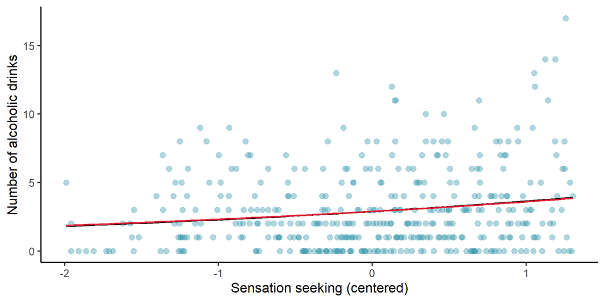

```r
nb_b0 <- summary(m3)$coefficients[1]
nb_b1 <- summary(m3)$coefficients[2]
ggplot(data = dat, aes(x = sensationC, y = alcohol)) +
    geom_point(size = 3,
               alpha = 0.4,
               color = "#3697aa") +
    labs(x = "Sensation seeking (centered)", y = "Number of alcoholic drinks") +
    geom_smooth(method = "glm",
                method.args = list(family = 'poisson'),
                se = FALSE,
                color = "black",
                fullrange = TRUE) +
    geom_function(fun = function(x) exp(nb_b0 + nb_b1 * x),
                color = "#dc1e34",
                size = 1)
```

## 5.15 Observed vs predicted

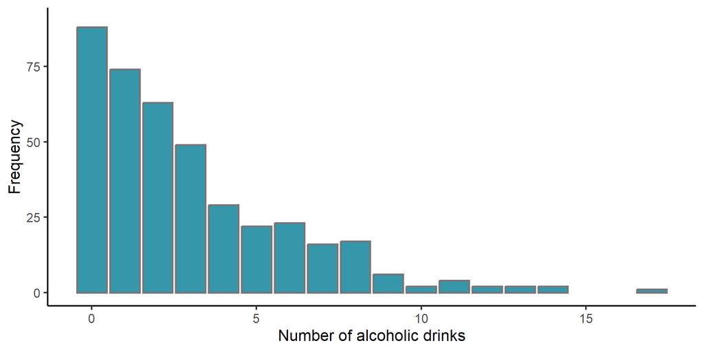

```r
ggplot(data = dat, aes(x = alcohol)) +
    geom_bar(fill = "#3697aa",
             color = "#76777a",
             size = 1) +
labs(x = "Number of alcoholic drinks", y = "Frequency") +
ylim(0, 90)
```

## 5.16 Observed vs predicted

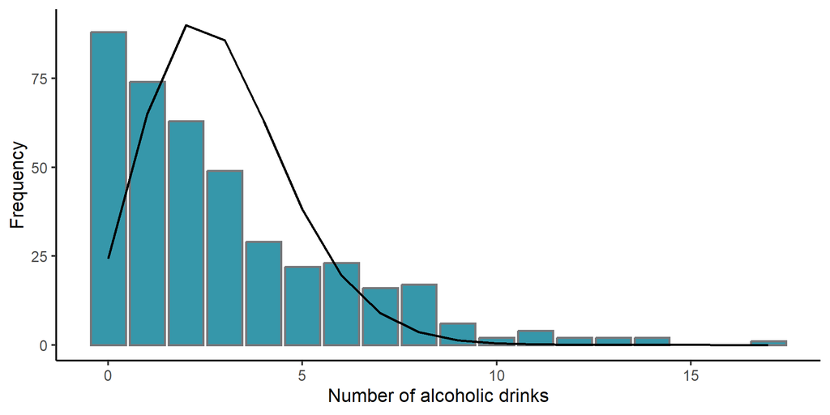

```r
library(pscl)       # predprob() function for predicted counts
                    # zeroinfl() function for zero-inflated count models
                    # hurdle() for hurdle count models
                    # vuong() for non-nested model comparisons
phat.poi <- predprob(m1)
phat.poi.mn <- apply(phat.poi, 2, mean)
#phat.poi.mn
phat.nb <- predprob(m3)
phat.nb.mn <- apply(phat.nb, 2, mean)
#phat.nb.mn
#phat.zinb <- predprob(zinb)
#phat.zinb.mn <- apply(phat.zinb, 2, mean)
#phat.zinb.mn
x <- seq(0, 17, 1)
probs <- data.frame(x, phat.poi.mn, phat.nb.mn)#, phat.zinb.mn)
#probs
ggplot(data = dat, aes(x = alcohol)) +
    geom_bar(fill = "#3697aa",
             color = "#76777a",
             size = 1) +
    geom_line(data = probs,
              aes(x = x, y = 400*phat.poi.mn),
              linetype = "solid",
              size = 1,
              color = "black") +
labs(x = "Number of alcoholic drinks", y = "Frequency") +
ylim(0, 90)
```

## 5.17 Observed vs predicted

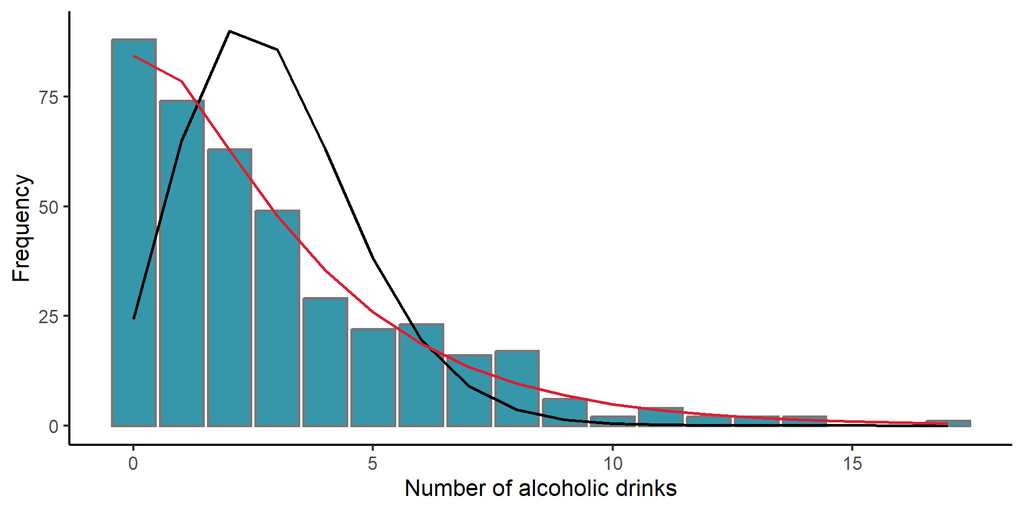

```r
ggplot(data = dat, aes(x = alcohol)) +
    geom_bar(fill = "#3697aa",
             color = "#76777a",
             size = 1) +
    geom_line(data = probs,
              aes(x = x, y = 400*phat.poi.mn),
              linetype = "solid",
              size = 1,
              color = "black") +
    geom_line(data = probs,
              aes(x = x, y = 400*phat.nb.mn),
              size = 1,
              #linetype = "dashed",
              color = "#dc1e34") +
labs(x = "Number of alcoholic drinks", y = "Frequency") +
ylim(0, 90)
```

## 5.18 Which model to pick?

- **Poisson regression**
  - You will likely never satisfy the equidispersion assumption
- **Overdispersed Poisson regression**
  - Preferred to Poisson regression
  - Appropriate standard errors and relatively simple model
- **Negative binomial regression**
  - More complex, but better able to reproduce the observed counts
  - This may be preferred if you’re interested in prediction

## 5.19 A word of caution…

Berk & MacDonald (2008)

> If apparent overdispersion results from **specification errors in the systematic part** of the Poisson regression model, resorting to the negative binomial distribution does not help. It can make things worse by giving a **false sense of security** when the fundamental errors in the model remain.
- In other words, negative binomial regression doesn’t *fix a bad model*

# 6 Zeroes

## 6.1 Zeroes can be really important

- Conceptually, zeroes are meaningful
- Lowest possible value of a count
- Indicate “nothing”
- Two situations:
  - Too few zeroes (relative to a Poisson distribution)
  - Too many zeroes (relative to a Poisson distribution)

## 6.2 Too few zeroes

- Sometimes you have a study where the outcome is a count, but it **cannot take on a value of 0**
  - Study of medical visits
    - **Have to visit the doctor** to get involved in the study
  - Study of substance use
    - Only interested in **substance users**
- **Truncated Poisson regression** model uses a *truncated Poisson distribution* that removes the probability of zeroes

## 6.3 Excess zeroes

- Counts often display **“excess” zeroes**
  - More values of 0 than expected for a Poisson distribution
- Even if the rest of the distribution is approximately Poisson, the “excess” zeroes lead to *overdispersion*
  - Sometimes, what looks like overdispersion is really excess zeroes
- There are specific Poisson family models to appropriately deal with excess zeroes, depending on *why* the zeroes are there

## 6.4 Why are there all these zeroes?

- This is a substantive question
  - You need to know about the outcome you’re studying
- Question: Do the **people who are responding zero** have **some probability** of responding otherwise?

## 6.5 Some probability of responding > 0?

- Yes $\rightarrow$ **zero-inflated Poisson regression**
  - Cigarettes smoked for smoker who hasn’t smoked yet **today**
  - Alcohol consumed for someone who hasn’t had any yet **today**
- No $\rightarrow$ **hurdle regression** or **with-zeroes regression**
  - Cigarettes smoked: nonsmoker always responds 0
  - Alcoholic drinks consumed: abstainer always responds 0
  - (These are called “structural zeroes”)

## 6.6 Zero-inflated Poisson regression

- There are zeroes have **some probability** to be non-zero
- Two parts modeled simultaneously:
  - Logistic regression: *Is each zero structural or not?*
  - Poisson regression: non-structural zeroes and positive values
- Can use same set of predictors in both parts, but do not have to
- Can also **model non-structural zeroes and positive values** using *overdispersed* Poisson regression or *negative binomial* regression

## 6.7 Hurdle regression (with-zeroes)

- There are zeroes that have **no probability** of being non-zero
  - Two different populations: smokers and nonsmokers, drinkers and nondrinkers
- Two parts modeled simultaneously:
  - Logistic regression: *whether zero or not*
  - Truncated Poisson regression: positive values only
- Can use same set of predictors in both parts, but do not have to

# 7 Variable lengths of time

## 7.1 Variable lengths of time

- Poisson regression and variants assume a *fixed length of time*
  - Number of aggressive acts committed by a child in 1 hour
  - Number of visits to doctor in past 6 months
  - Number of adverse events in a study
- Often, we measure a count over some *variable period of time*

## 7.2 Variable lengths of time

- Can extend Poisson type models to variable time periods
  - Include natural log of the measurement interval as a predictor with regression coefficient equal to 1:

$$ln(\hat{\mu}) = ln(time) + b_0 + b_1X_1 + b_2X_2 + \cdots + b_pX_p$$

- In software: include time (specifically, ln(time)) as an “offset”

# 8 Evaluation and comparison

## 8.1 Deviance

- As with logistic regression
  - Estimated with **maximum likelihood**
  - Use **deviance** to estimate pseudo-$R^2$
- Deviance is a function of the log-likelihood
  - How far model is from a *theoretical* **perfect model**
  - **Relative measure** so can only **compare** to another model
- Deviance usually = -2LL, but **not** for Poisson models

## 8.2 Pseudo $R^2$

$$R^2_{deviance} = 1 - \frac{deviance_{model}}{deviance_{intercept\ only}}$$

- Deviance for your model is “Residual deviance” from output
- Deviance for intercept model is “Null deviance” from output
- Theoretically ranges from 0 to 1 (but not always in practice)

## 8.3 Compare models

- Compare **deviances** of 2 **nested models** using likelihood ratio test
- e.g., compare `m1` (only `sensationC`) to `m1add` (`sensationC` and `sex`)

```r
anova(m1, m1add, test = "LRT")
```

```
Analysis of Deviance Table

Model 1: alcohol ~ sensationC
Model 2: alcohol ~ sensationC + sex
  Resid. Df Resid. Dev Df Deviance  Pr(>Chi)
1       398    1151.69
2       397     959.46  1   192.23 < 2.2e-16 ***
---
Signif. codes:  0 '***' 0.001 '**' 0.01 '*' 0.05 '.' 0.1 ' ' 1
```

## 8.4 Nested models

- Two models are **nested** if
  - All terms in one are **included in the other**
  - You can get from one to the other by **fixing some paths to a value**
- Why do we care?
  - Likelihood ratio tests can only be used to compare *nested models*
    - If your models are not nested, you **cannot** use the likelihood ratio tests to compare them
  - Instead, use **AIC**, **BIC** (smaller is better), Vuong test

## 8.5 Nested models

1. Linear regression with predictor $X_1$
2. Linear regression with predictors $X_1$ and $X_2$
- Model 1 is nested within model 2
  - If the coefficient for $X_2$ = 0 then Model 2 becomes Model 1

## 8.6 Complicated nesting situations 1

3. Poisson regression with predictors $X_3$ and $X_4$
4. Overdispersed Poisson regression w/ predictors $X_3$ and $X_4$
- Model 3 seems like it’s nested within model 4
  - But it’s not really
- Same number of things estimated: df = 0

## 8.7 Complicated nesting situations 2

5. Overdispersed Poisson regression w/ predictor $X_5$
6. Overdispersed Poisson regression w/ predictors $X_5$ and $X_6$
- Model 5 is NOT nested within model 6
- In addition to the extra predictor ($X_6$), the *overdispersion parameter* is not the same in these models
  - Model 5 has a $\psi$ parameter based on only $X_5$
  - Model 6 has a **different** $\psi$ parameter based on both $X_5$ and $X_6$
  - Can’t get from Model 6 to Model 5 by setting coefficient to 0

## 8.8 Complicated nesting situations 3

7. Overdispersed Poisson regression w/ predictors $X_7$ and $X_8$
8. Negative binomial regression w/ predictors $X_7$ and $X_8$
- Model 7 is NOT nested within model 8 (or vice versa)
- The overdispersion parameters are **different** for the two models
  - Model 7 has a $\psi$ parameter and estimates variance = $\psi \mu$
  - Model 8 has a $\alpha$ parameter and estimates variance = $\mu + \alpha \mu^2$

## 8.9 Vuong test

```r
library(pscl)
vuong(m1, m3)
```

```
Vuong Non-Nested Hypothesis Test-Statistic:
(test-statistic is asymptotically distributed N(0,1) under the
 null that the models are indistinguishible)
-------------------------------------------------------------
              Vuong z-statistic             H_A    p-value
Raw                   -6.911618 model2 > model1 2.3958e-12
AIC-corrected         -6.911618 model2 > model1 2.3958e-12
BIC-corrected         -6.911618 model2 > model1 2.3958e-12
```

# 9 Summary

## 9.1 Summary

- When your outcome is a **count**, use a model from the **Poisson regression** family
  - *Nonlinear, exponential model* or *log-linear model*
  - *Overdispersion*: overdispersed Poisson or negative binomial
  - Too many or too few *zeroes*
  - Variable lengths of time

## 9.2 In class

- Run some Poisson regression models
  - Poisson
  - Overdispersed Poisson
  - Negative binomial
- Interpret the results

## 9.3 Next time

- Logistic regression for **binary** outcomes
- Poisson regression for **count** outcomes
- Survival analysis for **survival** outcomes